# Reproducible Research: Peer Assessment 1

## Loading and preprocessing the data

```r
activity <- read.csv('activity.csv')
summary(activity)
```

```
##      steps               date          interval
##  Min.   :  0.0   2012-10-01:  288   Min.   :   0
##  1st Qu.:  0.0   2012-10-02:  288   1st Qu.: 589
##  Median :  0.0   2012-10-03:  288   Median :1178
##  Mean   : 37.4   2012-10-04:  288   Mean   :1178
##  3rd Qu.: 12.0   2012-10-05:  288   3rd Qu.:1766
##  Max.   :806.0   2012-10-06:  288   Max.   :2355
##  NA's   :2304    (Other)   :15840
```

```r
head(activity)
```

```
##   steps       date interval
## 1    NA 2012-10-01        0
## 2    NA 2012-10-01        5
## 3    NA 2012-10-01       10
## 4    NA 2012-10-01       15
## 5    NA 2012-10-01       20
## 6    NA 2012-10-01       25
```

We will treat the NA’s as zero for steps in the first part, so we will create a column in the data frame called `stepszero`

```r
activity$stepszero <- activity$steps
activity$stepszero[is.na(activity$stepszero)] <- 0
```

## What is mean total number of steps taken per day?

First we find the sum of the steps when each day is grouped together, stored as `sumsteps`.

```r
sumsteps <- by(activity$stepszero,INDICES=activity$date,FUN=sum)
days <- as.POSIXct(levels(activity$date))
```

We can see the number of steps for each day over time with a plot.

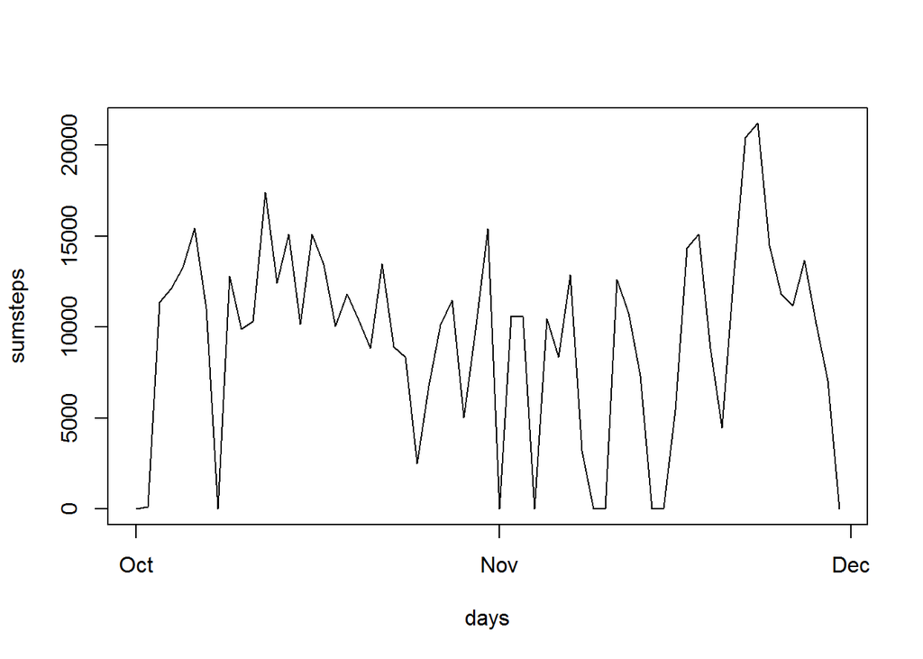

```r
plot(days,sumsteps,type='l')
```

To find the mean and median number of steps a day, we can just call mean and median on `sumsteps`.

```r
mean(sumsteps)
```

```
## [1] 9354
```

```r
median(sumsteps)
```

```
## 2012-10-20
##      10395
```

This tells us that the mean is 9354.2295 and the median is 1.0395 × 10<sup>4</sup>.

A histogram of the total number of steps on each day is shown here.

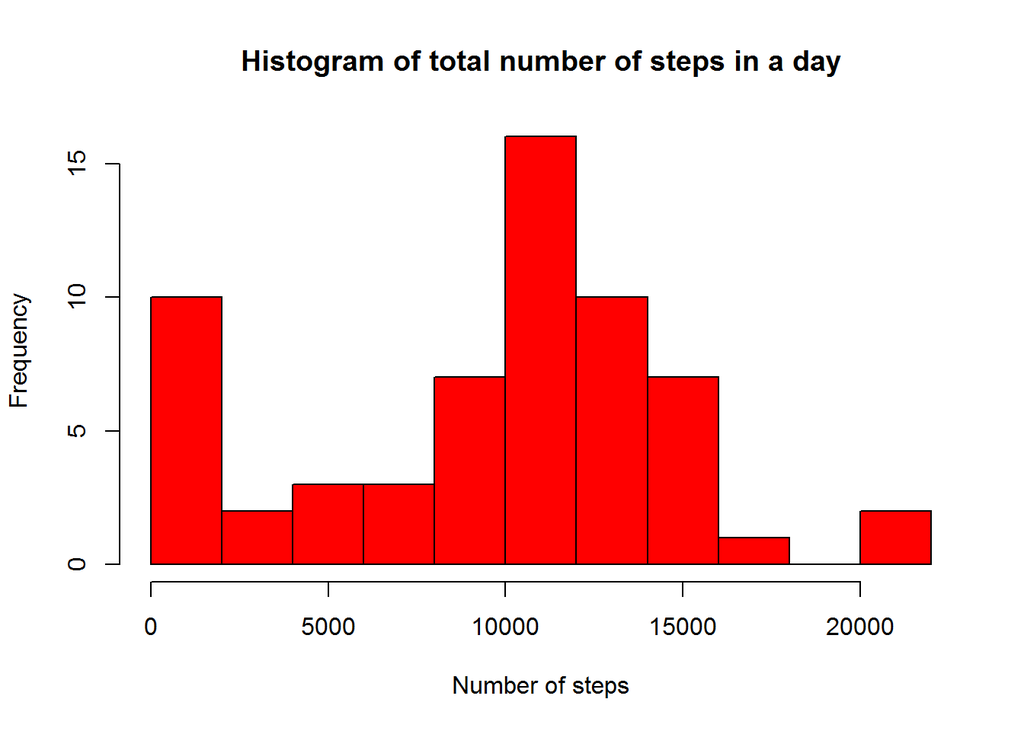

```r
hist(sumsteps,breaks=12,col='red',xlab='Number of steps',main='Histogram of total number of steps in a day')
```

## What is the average daily activity pattern?

To find the average daily activity pattern, we now want to group by the time instead of the date.

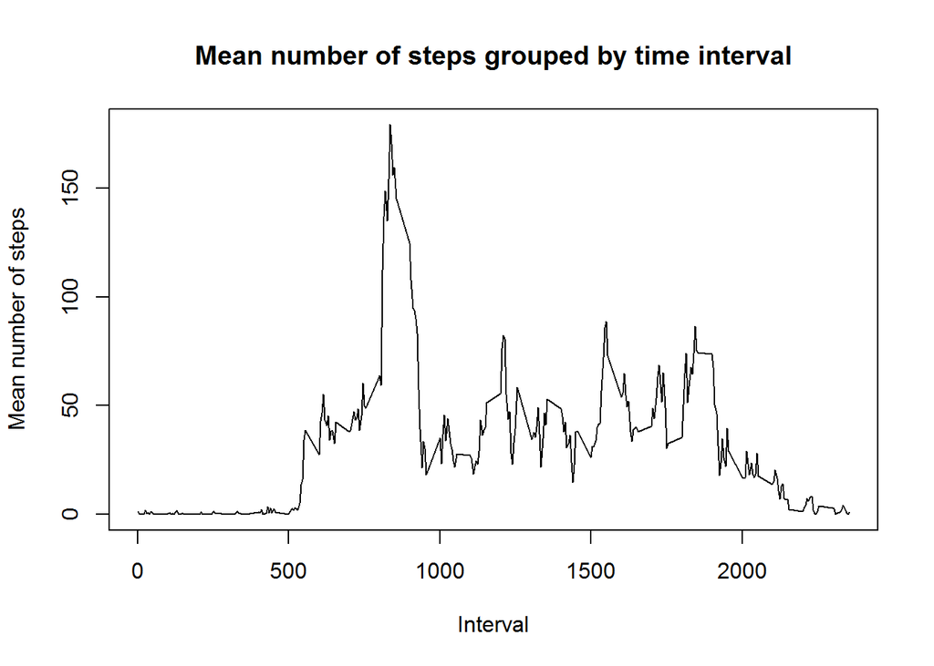

```r
meansteps <- by(activity$stepszero,activity$interval,mean,simplify=TRUE)
plot(x=activity$interval[1:length(meansteps)],meansteps,type='l',xlab='Interval',ylab='Mean number of steps',main='Mean number of steps grouped by time interval')
```

To find which interval has the largest average, we can use the `which.max` function.

```r
which.max(meansteps)
```

```
## 835
## 104
```

```r
activity$interval[which.max(meansteps)]
```

```
## [1] 835
```

We see that the interval with the largest mean is the 835 time interval.

## Imputing missing values

```r
sum(is.na(activity$steps))
```

```
## [1] 2304
```

There are 2304 missing values (NA’s) in the steps column. These can be replaced by using the mean for that time interval on the days that do have values. We need to first find the mean of the intervals from the values that aren’t NA. This is different than `meansteps` because those used zeros for NA’s. This new array is called `meansteps2`. Zero is used if all the values for the interval are NA. The new values for the steps without NA’s is saved in `activity$stepsclean`.

```r
meansteps2 <- by(activity$steps,activity$interval,function(x){
    toreturn <- mean(x,na.rm=TRUE)
    if (is.na(toreturn)) {
      return(0)
    } else {
      return(toreturn)
    }
  },simplify=TRUE)

intervals <- simplify2array(dimnames(meansteps2))

fixed.NAs <- apply(activity,1,function(x) {
  if (is.na(x['steps'])) {
    as.numeric(meansteps2[which(intervals==as.integer(x['interval']))])
  } else {
    x['steps']
  }
})

activity$stepsclean <- simplify2array(as.numeric(fixed.NAs))
```

Now we want to look at this new data when the data are grouped by date.

```r
stepscleanbyday <- by(activity$stepsclean,activity$date,sum)
mean(stepscleanbyday)
```

```
## [1] 10766
```

```r
median(stepscleanbyday)
```

```
## 2012-11-04
##      10766
```

The mean number of steps in a day for the adjusted data is 1.0766 × 10<sup>4</sup>. The median number of steps in a day for the adjusted data is 1.0766 × 10<sup>4</sup>.

This mean is much larger than before. This makes sense because before all the NA’s were coerced to be zero, but this time they were replaced with the average of the nonzero values. The median is larger but not by as big a margin. This is expected because there are fewer zeros, and the median is not as sensitive to a bunch of values being much smaller than the other ones.

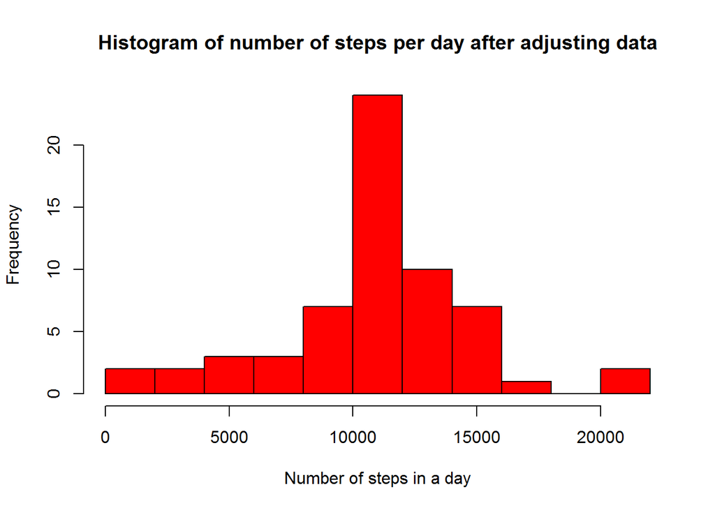

```r
hist(stepscleanbyday,breaks=10,col='red',xlab='Number of steps in a day',main='Histogram of number of steps per day after adjusting data')
```

## Are there differences in activity patterns between weekdays and weekends?

First we will add columns to the data frame indicating whether each day is a weekend or a weekday.

```r
activity$dayofweek <- weekdays(as.POSIXct(activity$date))
activity$weekend <- activity$dayofweek %in% c('Saturday','Sunday')
activity$weekday <- !(activity$dayofweek %in% c('Saturday','Sunday'))
```

Now we can plot the mean number of steps in each time interval with weekends and weekdays separate.

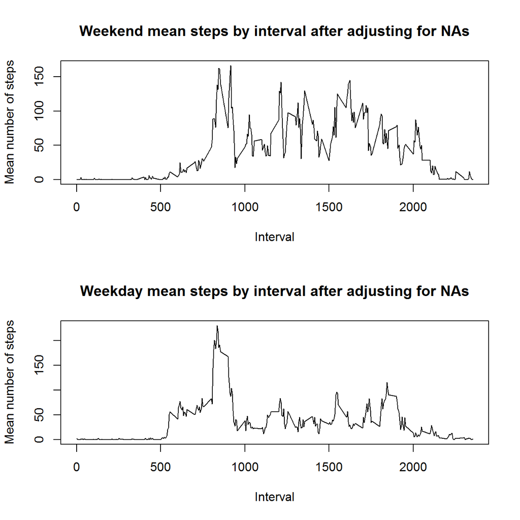

```r
par(mfrow=c(2,1))
weekendsteps <- by(activity$stepsclean[activity$weekend],activity$interval[activity$weekend],mean,simplify=T)
weekdaysteps <- by(activity$stepsclean[activity$weekday],activity$interval[activity$weekday],mean,simplify=T)
plot(x=simplify2array(dimnames(weekendsteps)),y=weekendsteps,type='l',xlab='Interval',ylab='Mean number of steps',main='Weekend mean steps by interval after adjusting for NAs')
plot(x=simplify2array(dimnames(weekendsteps)),y=weekdaysteps,type='l',xlab='Interval',ylab='Mean number of steps',main='Weekday mean steps by interval after adjusting for NAs')
```

We can see that there are fewer steps taken on week days. Both show a peak around 900, and very low values from 0 to 500.